# DiabeticRetinopathy

Hannah Kim

8/17/2021

## Introduction

This project uses the Diabetic Retinopathy dataset from the UCI Machine Learning Repository. Theses are the physician-scientists that collected the datapoints:

- Dr. Balint Antal, Department of Computer Graphics and Image Processing Faculty of Informatics, University of Debrecen, 4010, Debrecen, POB 12, Hungary antal.balint ‘@’ inf.unideb.hu
- Dr. Andras Hajdu, Department of Computer Graphics and Image Processing Faculty of Informatics, University of Debrecen, 4010, Debrecen, POB 12, Hungary hajdu.andras ‘@’ inf.unideb.hu

This dataset was collected in 11/03/2014.

## General Dataset Information

```r
library(readr)
messidor_features <- read_csv("messidor_features.csv", col_names = FALSE)
```

Currently, the dataset contains 20 attributes or features that are numbered from X1 to X20.

```r
colnames(messidor_features)
```

```
##  [1] "X1"  "X2"  "X3"  "X4"  "X5"  "X6"  "X7"  "X8"  "X9"  "X10" "X11" "X12"
## [13] "X13" "X14" "X15" "X16" "X17" "X18" "X19" "X20"
```

Going from X1 to X20, the attributes or columns represent: Image quality assessment Pre-screening assessment Microaneurysm detection in 6 different lighting conditions(col 3-8) Exudate detection in 8 different lighting conditions (col 9-16) Distance between macula and optic disc Optic disc diameter Class label based on AM/FM Class label (Diagnosis of diabetic retinopathy)

## Summary of libraries used

Readr (Data importing) Tidyverse (Data cleaning) Ggplot2 & pastecs (Assessing the normalization of features) RColorBrewer (Using colorblind friendly palettes)

```r
library(tidyverse)
```

```r
library(ggplot2)
library(pastecs)
library(RColorBrewer)
```

## Data Cleaning

To organize the multiple data points about the number of microaneurysms present in one fundus photo, I used the mutate() function compute the average and place the values at the end of the table.

```r
messidor_features <- messidor_features %>% mutate((X3+X4+X5+X6+X7+X8)/6)
```

Similarly, to organize the multiple data points about the number of exudates present in one fundus photo, I used the mutate() function compute the average and place the values at the end of the table.

```r
messidor_features <- messidor_features %>% mutate((X9+X10+X11+X12+X13+X14+X15+X16)/8)
```

The columns that were used to compute the average was then removed.

```r
DiabRet <- messidor_features[ -c(3:16) ]
```

Then the columns were renamed appropriately to reflect the description of the attribute or column.

```r
DiabRet <- rename(DiabRet, ImageQuality = X1)
DiabRet <- rename(DiabRet, Prescreening = X2)
DiabRet <- rename(DiabRet, DistanceOD_Macula = X17)
DiabRet <- rename(DiabRet, ODDiameter = X18)
DiabRet <- rename(DiabRet, ClassAMFM = X19)
DiabRet <- rename(DiabRet, ClassFinal = X20)
DiabRet <- rename(DiabRet, AvgMicroaneurysms = "(X3 + X4 + X5 + X6 + X7 + X8)/6")
DiabRet <- rename(DiabRet, AvgExudates = "(X9 + X10 + X11 + X12 + X13 + X14 + X15 + X16)/8")
colnames(DiabRet)
```

```
## [1] "ImageQuality"      "Prescreening"      "DistanceOD_Macula"
## [4] "ODDiameter"        "ClassAMFM"         "ClassFinal"
## [7] "AvgMicroaneurysms" "AvgExudates"
```

## Data Summary

This is a summary of the data:

```r
summary(DiabRet)
```

```
##   ImageQuality     Prescreening    DistanceOD_Macula   ODDiameter
##  Min.   :0.0000   Min.   :0.0000   Min.   :0.3678    Min.   :0.05791
##  1st Qu.:1.0000   1st Qu.:1.0000   1st Qu.:0.5029    1st Qu.:0.09579
##  Median :1.0000   Median :1.0000   Median :0.5233    Median :0.10662
##  Mean   :0.9965   Mean   :0.9183   Mean   :0.5232    Mean   :0.10844
##  3rd Qu.:1.0000   3rd Qu.:1.0000   3rd Qu.:0.5437    3rd Qu.:0.11963
##  Max.   :1.0000   Max.   :1.0000   Max.   :0.5922    Max.   :0.21920
##    ClassAMFM       ClassFinal        AvgMicroaneurysms  AvgExudates
##  Min.   :0.0000   Length:1150        Min.   :  1.00    Min.   : 0.04366
##  1st Qu.:0.0000   Class :character   1st Qu.: 13.38    1st Qu.: 4.14971
##  Median :0.0000   Mode  :character   Median : 29.17    Median : 8.75643
##  Mean   :0.3357                      Mean   : 32.12    Mean   :12.33042
##  3rd Qu.:1.0000                      3rd Qu.: 47.67    3rd Qu.:17.21925
##  Max.   :1.0000                      Max.   :108.00    Max.   :83.90385
```

As you can see there is a greater spread of data with the avg microaneurysms and avg exudates values compared to the distance between OD to macula values or the OD diameter values.

## Data Visualization with Histograms

As taught in class, histograms enable us to visualize the spread of data.

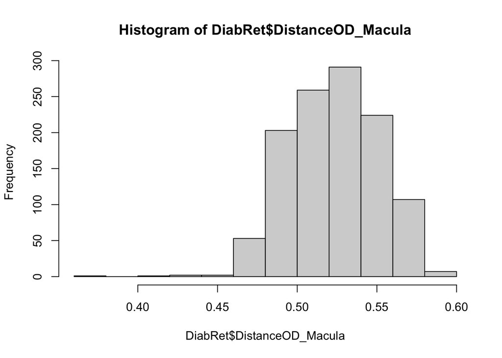

```r
hist(DiabRet$DistanceOD_Macula)
```

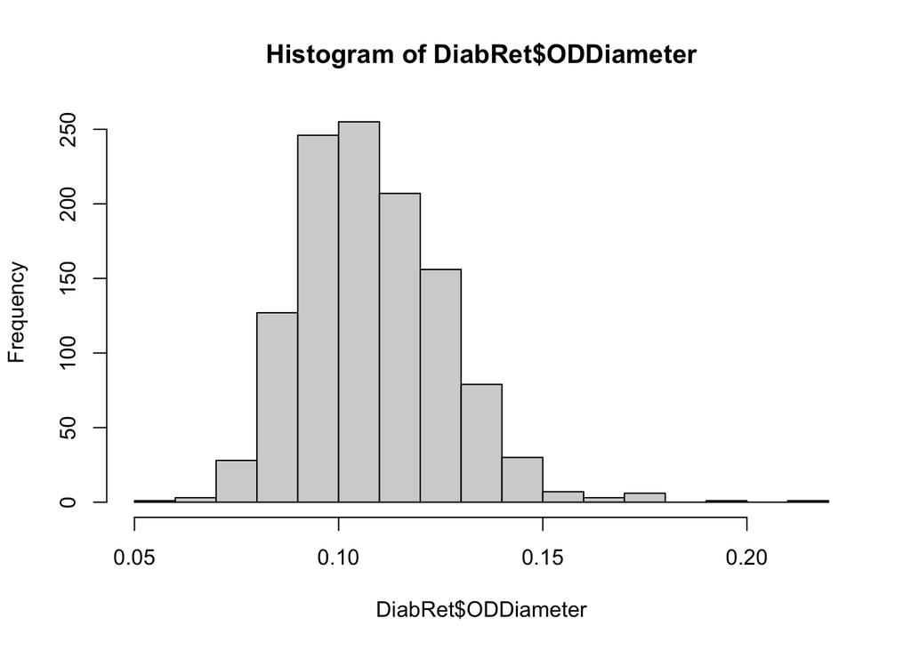

```r
hist(DiabRet$ODDiameter)
```

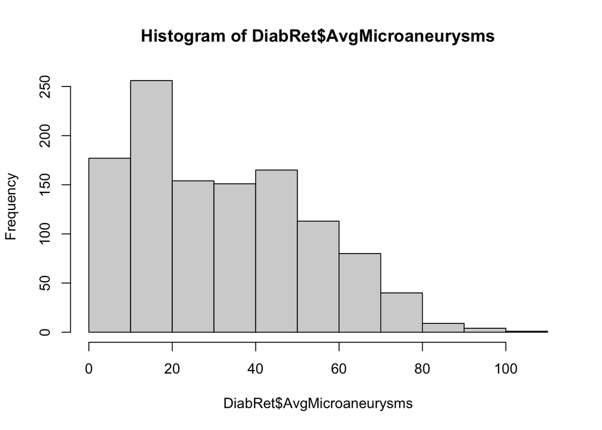

```r
hist(DiabRet$AvgMicroaneurysms)
```

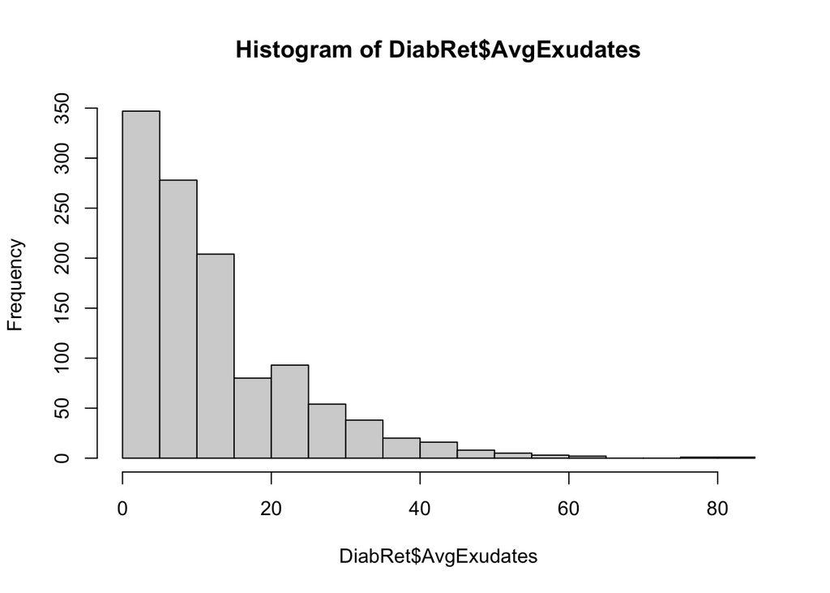

```r
hist(DiabRet$AvgExudates)
```

This is the histograms of the 4 main variables or attributes in the dataset. The OD diameter variable seems to be the most normally distributed. Then the distance between OD to macula variable are the next most normally distributed. Both the avg microaneurysm and avg exudates variables are skewed to the right.

## Data Visualization with Geompoint()

This plot compares the avg microaneurysms (located in the x axis) to the avg exudates (located on the y axis) The purple dots are images that were diagnosed with diabetic retinopathy. The orangle red dots are images that were normal/healthy retinas.

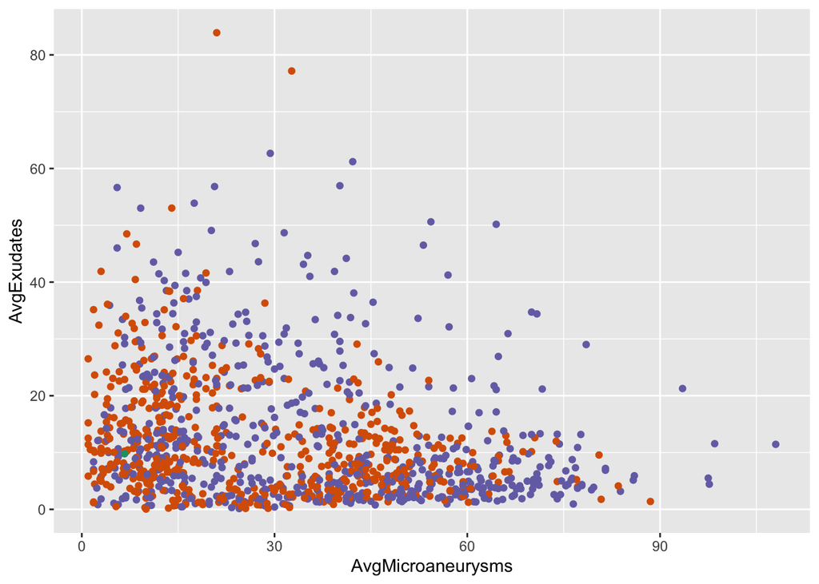

```r
ggplot(DiabRet, aes(x = AvgMicroaneurysms, y = AvgExudates, col = ClassFinal))+geom_point() + scale_color_brewer(breaks = 3,palette = "Dark2")
```

This plot compares the distance between OD to macula variable (located on the x) to the OD diameter variable (located on the y)

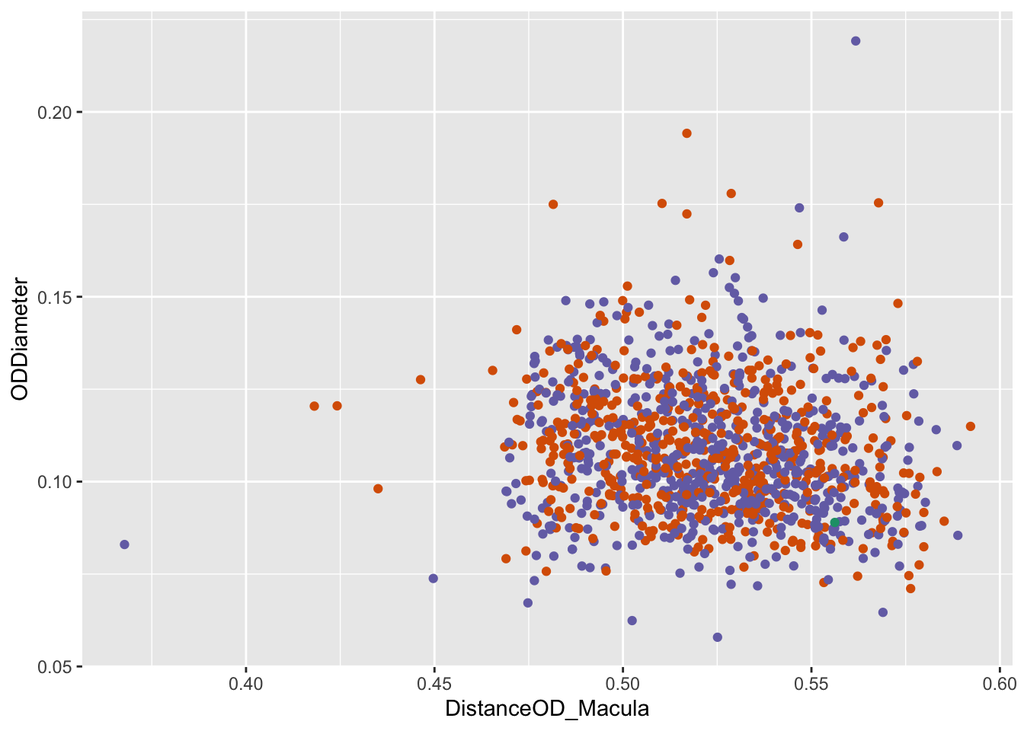

```r
ggplot(DiabRet, aes(x = DistanceOD_Macula, y = ODDiameter, col = ClassFinal))+geom_point() + scale_color_brewer(breaks = 3,palette = "Dark2")
```

## Multiple Regression Model

The multiple regression model was used to observe how different variables affect the number of microaneurysms present or detected in the retina.

```r
DRModel <- lm(AvgMicroaneurysms ~ AvgExudates + DistanceOD_Macula + ODDiameter + ClassFinal, data = DiabRet)
summary(DRModel)
```

```
##
## Call:
## lm(formula = AvgMicroaneurysms ~ AvgExudates + DistanceOD_Macula +
##     ODDiameter + ClassFinal, data = DiabRet)
##
## Residuals:
##     Min      1Q  Median      3Q     Max
## -40.083 -15.997  -1.857  14.843  70.245
##
## Coefficients:
##                    Estimate Std. Error t value Pr(>|t|)
## (Intercept)        24.37035   23.51076   1.037    0.300
## AvgExudates        -0.47438    0.05287  -8.973   <2e-16 ***
## DistanceOD_Macula -23.41758   21.22205  -1.103    0.270
## ODDiameter         -0.41679   33.09103  -0.013    0.990
## ClassFinal0\\      20.57591   19.85094   1.037    0.300
## ClassFinal1\\      30.63148   19.84772   1.543    0.123
## ---
## Signif. codes:  0 '***' 0.001 '**' 0.01 '*' 0.05 '.' 0.1 ' ' 1
##
## Residual standard error: 19.81 on 1144 degrees of freedom
## Multiple R-squared:  0.1149, Adjusted R-squared:  0.1111
## F-statistic: 29.71 on 5 and 1144 DF,  p-value: < 2.2e-16
```

In this model, the dependent variable is the number of microaneurysms. The independent variables are the other 3 main variables and the diagnoses.

Error Analysis: This table is tricky to read because an increase of one cm between the distance between OD and the macula would decrease the number of microaneurysms by 23. This doesn’t make sense because the distance between the OD and the macula will never be greater than 4 to 5 mm. If all the variables were normalized to have the same scale of values, it would show that this distance variable is largely insignificant.